# Code Example: Snippet of RNA-Seq Analysis

Bojan Zunar

5 May 2019

The following is an excerpt of code used to compare the expression of genes between the dorsolateral prefrontal cortex of six fetal and six adult human brain samples. The data were generated by [Jaffe et al. (2014)](http://dx.doi.org/10.1038/nn.3898). The code imports read counts obtained by featureCounts, performs exploratory analysis of the samples, looks for differentially expressed genes, and calculates how many differentially expressed genes contain H3K4me3 mark.

```r
library(AnnotationHub); library(AnnotationDbi); library(apeglm); library(biomaRt); library(DESeq2); library(EnhancedVolcano); library(GenomicRanges); library(ggbeeswarm); library(ggsci); library(magrittr); library(org.Hs.eg.db); library(OrganismDbi); library(rtracklayer); library(SummarizedExperiment); library(tidyverse)
```

# 1 Importing into R featureCounts and Sample Metadata

After using featureCounts to count aligned RNA-seq reads, the counts were loaded into R.

```r
# build the phenotype table for all 36 samples
meta_tsv <- file.path("D:", "srr", "metadata.tsv")
col_tsv <- file.path("D:", "srr", "col_names.tsv")

metadata <- readr::read_tsv(meta_tsv, col_names = FALSE)
col_names <- readr::read_tsv(col_tsv, col_names = FALSE) %>% as.character()
col_names[1:2] <- c("SRX", "SRA")

# filter only fetal and adult samples
metadata %<>%
    magrittr::set_colnames(col_names) %>%
    filter(SRX %in% list.files(path = file.path("D:", "srr"))) %>%
    mutate(status = ifelse(age < 0, "fetus", "adult")) %>%
    arrange(SRX)

# import tab-delimited files produced by featureCounts
featureCounts.import <- function(x) {readr::read_tsv(x, comment = "#")[, 7]}

featureCounts.files <- list.files(path = file.path("D:", "srr"),
                                  pattern = ".hisat2.featureCounts.multimapping.txt$",
                                  recursive = TRUE, full.names = TRUE)

geneid <- readr::read_tsv(featureCounts.files[1], comment = "#")[, 1]

counts <- lapply(featureCounts.files, featureCounts.import) %>%
    dplyr::bind_cols(geneid, .)

# clean up column names
cols <- colnames(counts) %>%
    stringr::str_extract(pattern = "SRX.*/h") %>%
    stringr::str_sub(1,-3)

cols[1] <- "Geneid"
colnames(counts) <- cols
```

# 2 Exploratory Analysis

Loaded counts were used to create DESeq2 dataset and to visualise sample-to-sample distances through principal component analysis. Scatter plot of the top two principal components uncovered two clusters, one corresponding to adult tissues, the other one to the fetal tissues. One low-quality adult sample failed to cluster with others. The samples did not cluster by sex or quality of sequenced RNA (RIN).

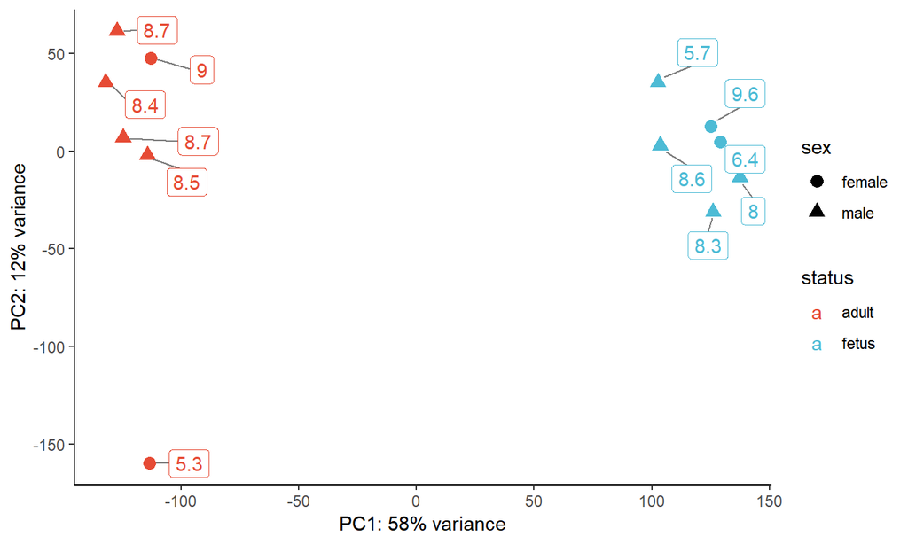

```r
lengths <- readr::read_tsv(featureCounts.files[1], comment = "#")[, 6]

# build a SummarizedExperiment
se <- SummarizedExperiment(assays = list(counts = as.matrix(counts[, 2:13])),
                           rowData = DataFrame(counts$Geneid, lengths, row.names = counts$Geneid),
                           colData = DataFrame(metadata, row.names = metadata$SRX))

# relevel SummarizedExperiment
se$status %<>% as.factor() %>% relevel("adult")

# create DESeq2 dataset
dds <- DESeqDataSet(se, design = ~ status)
dds <- dds[rowSums(counts(dds)) > 1,]     # basic filtering

# rlog transform and PCA
rldPca <- dds %>%
    rlog() %>%
    plotPCA(intgroup = c("status", "sex", "RIN"),
            returnData = TRUE, ntop = 50000)

# plot principal components
percentVar <- round(100 * attr(rldPca, "percentVar"))

ggplot(rldPca, aes(x = PC1, y = PC2, color = status, shape = sex)) +
    geom_point(size = 3) +
    geom_label_repel(aes(label = RIN),
                     point.padding = 0.5,
                     nudge_x = 10,
                     segment.color = 'grey50') +
    theme_classic() +
    xlab(paste0("PC1: ", percentVar[1], "% variance")) +
    ylab(paste0("PC2: ", percentVar[2], "% variance")) +
    ggsci::scale_colour_npg() +
    theme(legend.position = "right")
```

# 3 Detecting Differentially Expressed Genes

Differential expression was evaluated with DESeq2, and obtained results were explored through the MA plot, the histogram of p-values, and volcano plot. The MA plot was used to visualise shrunken log2 fold changes that were calculated with DESeq2::lfcShrink(). It confirmed that many genes were significantly differentially expressed and that log-fold change did not depend on the mean of normalised counts.

```r
# analyse differential expression with DESeq2
dds <- DESeq(dds)
res <- results(dds)

summary(res)
```

```
##
## out of 51836 with nonzero total read count
## adjusted p-value < 0.1
## LFC > 0 (up)       : 12047, 23%
## LFC < 0 (down)     : 12190, 24%
## outliers [1]       : 312, 0.6%
## low counts [2]     : 7035, 14%
## (mean count < 1)
## [1] see 'cooksCutoff' argument of ?results
## [2] see 'independentFiltering' argument of ?results
```

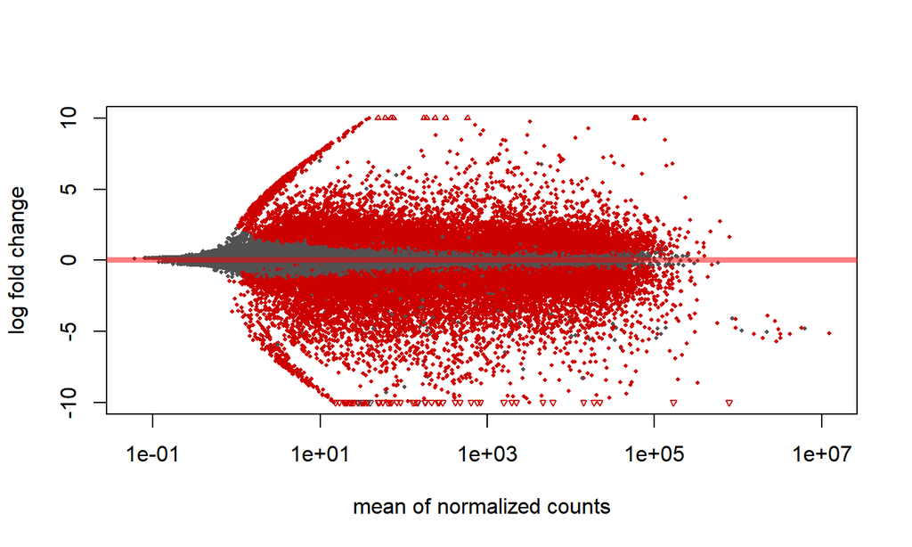

```r
# plot MA plot
res <- lfcShrink(dds, coef = "status_fetus_vs_adult", type = "apeglm")
plotMA(res, ylim = c(-10, 10))
```

Histogram of p-values showed p-values were uniformly distributed on the right of the plot, thus validating the choice of covariates.

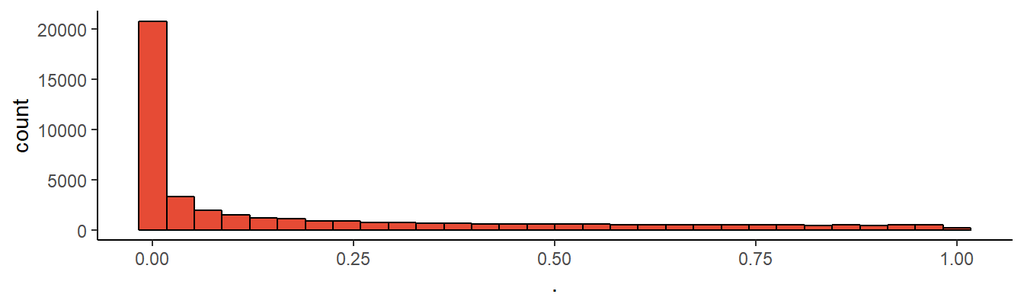

```r
# plot histogram of p-values
res$pvalue[res$baseMean > 1] %>%
    as.data.frame() %>%
    ggplot(aes(x = .)) +
    geom_histogram(fill = "#E64B35FF", color = "black") +
    theme_classic()
```

Finally, the volcano plot highlighted the most significantly differentially expressed genes that showed the largest fold-change. Ensemble labels were replaced with the human-readable gene names.

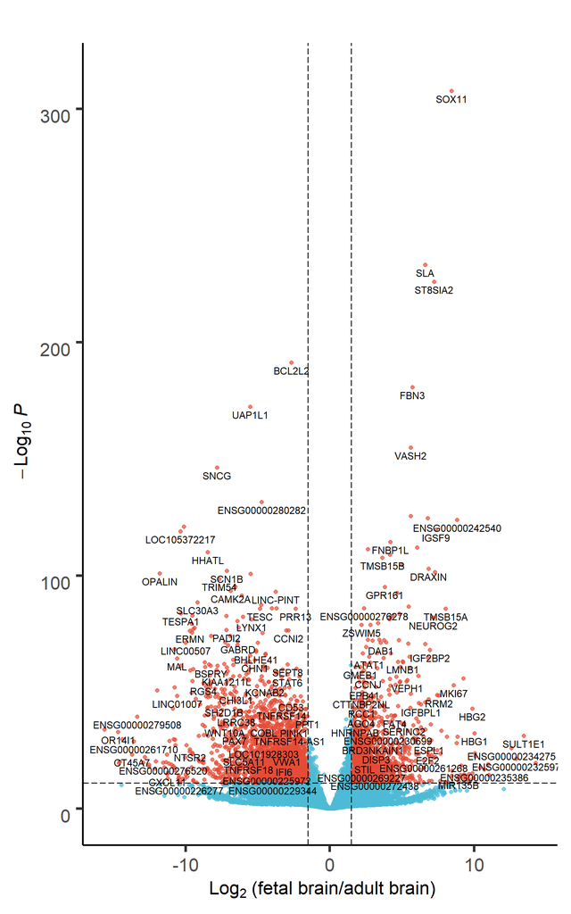

```r
# map human-readable gene symbols to ensemble names
res$symbol <- mapIds(org.Hs.eg.db, keys = row.names(res), column = "SYMBOL",
                     keytype="ENSEMBL", multiVals = "first")
res$ensemble <- row.names(res)
res$symbol <- ifelse(is.na(res$symbol), res$ensemble, res$symbol)

res$entrez <- mapIds(org.Hs.eg.db, keys = row.names(res), column = "ENTREZID",
                     keytype="ENSEMBL", multiVals="first")

# volcano plot
EnhancedVolcano(res,
                lab = res$symbol,
                x = 'log2FoldChange',
                y = 'pvalue',
                xlab = bquote(~Log[2]~ '(fetal brain/adult brain)'),
                pCutoff = 10e-12,
                FCcutoff = 1.5,
                transcriptPointSize = 1.5,
                transcriptLabSize = 3.0,
                col=c('#4DBBD5FF', '#4DBBD5FF', '#4DBBD5FF', '#E64B35FF'),
                colAlpha = 0.7,
                legendPosition = 'right',
                gridlines.major = FALSE,
                gridlines.minor = FALSE) +
    theme(legend.position = "none")
```

# 4 Overlapping H3K4me3 Data with Promoters of Differentially Expressed Genes

Annotation of the human genome (version hg38, on which the RNA-seq reads were mapped) was downloaded through Biomart. The H3K4me3 ChIP-Seq data, generated by Roadmap Epigenomics (H3K4me3.narrowPeak.gz), was comprised of human fetal and adult brain samples, as well as of a sample of the adult liver (which served as a control). Methylation data was downloaded through AnnotationHub and was lifted over from hg19 to hg38 version of the human genome reference.

```r
# set the folder for dowloading the data sets
setAnnotationHubOption("CACHE", "D:/RStudio/AnnotationHub")

# search the AnnotationHub
ah <- AnnotationHub()
hg <- subset(ah, species == "Homo sapiens") %>%
    query("H3K4me3")

# AH30479 | E082-H3K4me3.narrowPeak.gz == brain fetal female narrow
bffn <- subset(hg, title == "E082-H3K4me3.narrowPeak.gz")[[1]]

# AH30413 | E073-H3K4me3.narrowPeak.gz == brain adult narrow
ban <- subset(hg, title == "E073-H3K4me3.narrowPeak.gz")[[1]]

# AH30367 | E066-H3K4me3.narrowPeak.gz == liver adult narrow
lan <- subset(hg, title == "E066-H3K4me3.narrowPeak.gz")[[1]]

# makeOrganismDbFromBiomart for hg38
hg38 <- makeOrganismDbFromBiomart()
newStyle <- mapSeqlevels(seqlevels(hg38), "UCSC")
newStyle <- newStyle[!is.na(newStyle)]

# get the chain file for the liftover
ahub.chain <- subset(ah, rdataclass == "ChainFile" & species == "Homo sapiens")
chain <- ahub.chain[ahub.chain$title == "hg19ToHg38.over.chain.gz"]
chain <- chain[[1]]

# liftover Roadmap Epigenomics data
bffn.hg38 <- liftOver(bffn, chain) %>% unlist()
ban.hg38 <- liftOver(ban, chain) %>% unlist()
lan.hg38 <- liftOver(lan, chain) %>% unlist()
```

```r
# define the groups of differentially expressed data
resSig <- subset(res, padj < 0.1)
resSig <- resSig[order(resSig$log2FoldChange),]
resSig_fetal <- resSig[resSig$log2FoldChange > 0,]
resSig_adult <- resSig[resSig$log2FoldChange < 0,]

# function that subsets promoters of differentially expressed genes
depromoters <- function(x) {
    x %>%
        rownames() %>%
        {subset(genes(hg38, columns = c("ENSEMBL", "SYMBOL")), any(ENSEMBL %in% .))} %>%
        promoters() %>%
        keepStandardChromosomes(pruning.mode = "coarse") %>%
        renameSeqlevels(newStyle)
}

# dfp (differential fetal promoters)
dfp <- depromoters(resSig_fetal)

# dap (differential adult promoters)
dap <- depromoters(resSig_adult)

# promoters of all genes == prom
prom <- hg38 %>%
    genes(columns = c("ENSEMBL", "SYMBOL")) %>%
    promoters() %>%
    keepStandardChromosomes(pruning.mode = "coarse") %>%
    renameSeqlevels(newStyle)
```

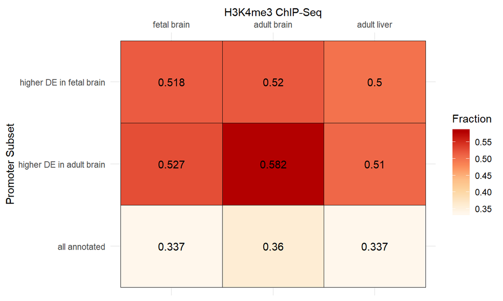

```r
# define function for overlapping differentially expressed genes with the methylation data
dvm <- function(de, h3k4me3) {
    findOverlaps(de, h3k4me3) %>%
        queryHits() %>%
        unique() %>%
        length() %>%
        divide_by(length(de))
}

# define colors for the matrix (from RColorBrewer, brewer.pal(9, "OrRd") %>% .[1:8])
brew.orrd <- c("#FFF7EC", "#FEE8C8", "#FDD49E", "#FDBB84",
               "#FC8D59", "#EF6548", "#D7301F", "#B30000") %>% colorRampPalette
brew.orrd <- brew.orrd(100)

# calculate proportion of promoters that contain H3K4me3 peaks
prop <- purrr::cross2(list(dfp, dap, prom),
       list(bffn.hg38, ban.hg38, lan.hg38)) %>%
    transpose() %>%
    {purrr::map2(.[[1]], .[[2]], dvm)} %>%
    unlist() %>%
    matrix(nrow = 3, byrow = FALSE) %>%
    set_rownames(c("higher DE in fetal brain",
                   "higher DE in adult brain",
                   "all annotated")) %>%
    set_colnames(c("fetal brain",
                   "adult brain",
                   "adult liver"))

# plot the proportions
prop %>%
    as.data.frame() %>%
    round(digits = 3) %>%
    rownames_to_column() %>%
    tidyr::gather("key", "fraction", -rowname) %>%
    mutate(key = factor(key, levels = c("fetal brain", "adult brain", "adult liver"))) %>%
    ggplot(aes(x = key, y = rowname, fill = fraction)) +
    geom_tile() +
    geom_text(aes(label = fraction)) +
    scale_fill_gradientn(colors = brew.orrd[0:100]) +
    scale_x_discrete(position = "top") +
    geom_tile(color = "black", fill = "black", alpha = 0) +
    labs(x = "H3K4me3 ChIP-Seq", y = "Promoter Subset", fill = "Fraction") +
    theme_minimal() +
    theme(legend.position = "right", plot.title = element_text(face = "bold"))
```